# PU5923 Assessment 3: Project Planning and Management

Author

Student ID: 52198593

This document provides a description of the project planning and management processes applied to the work-based placement.

The first step was to establish a research question using the PECO (Population, Exposure, Comparator, Outcome) framework. A literature review was carried out, covering the main themes of antipsychotic use and impact on metabolism, specifically impact on blood glucose and weight gain, to establish the state of knowledge on risks of developing diabetes mellitus.

Following the literature review and after exploring the available datasets, I created a PERT chart to begin mapping out the process for designing a project, which can be seen in Figure 1.

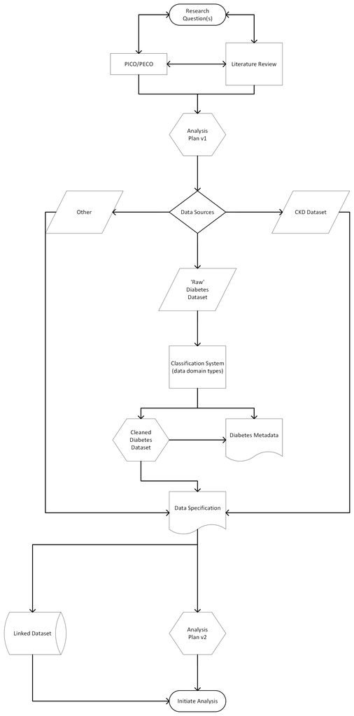

Figure 1: PERT chart showing the processes involved in planning the placement project.

I learned that this is the ‘ideal’ version of how to plan a data analysis project; the reality was that I needed to return to the PECO and literature several times after spending time in the datasets and learning about the variables available in order to develop a better understand what I was trying to achieve. A more accurate process can be seen in Figure 2.

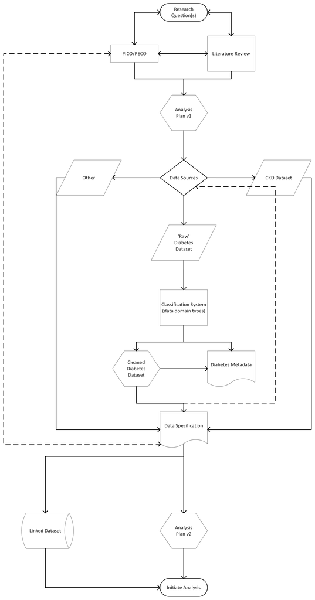

Figure 2: Revised PERT chart showing the almost circular approach to developing research questions after having spent time in unfamiliar datasets.

From this PERT chart I created a more detailed work plan to track progress and stay on task Figure 3.

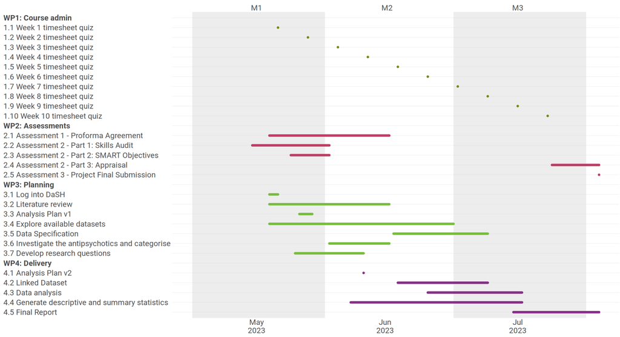

Figure 3: Gantt chart for placement project

I also used Microsoft Lists to create task trackers with automated alerts to remind me of deadlines.

From this process I have developed a better sense of tasks and timelines required to complete this type of work.